# Working with dataframes in python using Pandas

Pandas is built on top of the **NumPy** package, meaning a lot of the structure of NumPy is used or replicated in Pandas. Data in pandas is often used to feed statistical analysis in **SciPy**, plotting functions from **Matplotlib**, and machine learning algorithms in **Scikit-learn**.

> Note: this lesson will just scratch the surface of what is possible with Pandas. It's focused on most common commands and operations and should be seen as a starting point for further investigation.

```python
# Pandas is usually imported like this:
import pandas as pd
```

## Core components of pandas

The primary two components of pandas are the `Series` and `DataFrame`.

A `Series` is essentially a column, and a `DataFrame` is a multi-dimensional table made up of a collection of `Series`.

## Creating DataFrames from scratch

There are many ways to create a `DataFrame` from scratch, but a great option is to just use a simple `dict`.

```python
data = {
    'apples': [3, 2, 0, 1],
    'oranges': [0, 3, 7, 2]
}

purchases = pd.DataFrame(data)

purchases
```

|  | apples | oranges |
| --- | --- | --- |
| 0 | 3 | 0 |
| 1 | 2 | 3 |
| 2 | 0 | 7 |
| 3 | 1 | 2 |

The `Index` of this `DataFrame` was given to us on creation as the numbers 0-3, but we could also create our own when we initialize the `DataFrame`.

Let's have customer names as our index:

```python
purchases = pd.DataFrame(data, index=['June', 'Robert', 'Lily', 'David'])

purchases
```

|  | apples | oranges |
| --- | --- | --- |
| June | 3 | 0 |
| Robert | 2 | 3 |
| Lily | 0 | 7 |
| David | 1 | 2 |

So now we could locate a customer's order by using their name:

```python
purchases.loc['June']
```

```
apples     3
oranges    0
Name: June, dtype: int64
```

## How to read in data

It’s quite simple to load data from various file formats into a `DataFrame`. In the following examples we'll keep using our apples and oranges data, but this time it's coming from various files.

### Reading data from csv

```python
df = pd.read_csv('purchases.csv')

df
```

|  | Unnamed: 0 | apples | oranges |
| --- | --- | --- | --- |
| 0 | June | 3 | 0 |
| 1 | Robert | 2 | 3 |
| 2 | Lily | 0 | 7 |
| 3 | David | 1 | 2 |

CSVs don't have indexes like our `DataFrames`, so all we need to do is just designate the `index_col` when reading:

```python
# we're setting the index to be column zero (the customers names)
df = pd.read_csv('purchases.csv', index_col=0)

df
```

|  | apples | oranges |
| --- | --- | --- |
| June | 3 | 0 |
| Robert | 2 | 3 |
| Lily | 0 | 7 |
| David | 1 | 2 |

### Reading data from json

```python
df = pd.read_json('purchases.json')

df
```

|  | apples | oranges |
| --- | --- | --- |
| David | 1 | 2 |
| June | 3 | 0 |
| Lily | 0 | 7 |
| Robert | 2 | 3 |

### Reading data from database

If you’re working with data from a SQL database you need to first establish a connection using an appropriate Python library, then pass a query to pandas. Here we'll use SQLite to demonstrate.

```python
import sqlite3

con = sqlite3.connect("database.db")

df = pd.read_sql_query("SELECT * FROM purchases", con)

df
```

|  | index | apples | oranges |
| --- | --- | --- | --- |
| 0 | June | 3 | 0 |
| 1 | Robert | 2 | 3 |
| 2 | Lily | 0 | 7 |
| 3 | David | 1 | 2 |

Just like with CSVs, we could pass `index_col='index'`, but we can also set an index after-the-fact:

```python
df = df.set_index('index')

df
```

| index | apples | oranges |
| --- | --- | --- |
| June | 3 | 0 |
| Robert | 2 | 3 |
| Lily | 0 | 7 |
| David | 1 | 2 |

### Reading from Excel

```python
df = pd.read_excel('purchases.xlsx', index_col=0)

df
```

|  | apples | oranges |
| --- | --- | --- |
| June | 3 | 0 |
| Robert | 2 | 3 |
| Lily | 0 | 7 |
| David | 1 | 2 |

### Setting an index based on more than one column

Sometimes your data doesn't have a unique column and you don't want the default numeric index that Pandas provide. One option is to create a unique column through the concatenation of two or more columns, or you can tell pandas that your dataframe has an index based on several columns. For example:

```python
df = pd.read_excel('purchases.xlsx', index_col=[0,1])

df
```

[output not shown]

This will, however, add extra complexity to your dataframe and changes in the way that you select data. See [this notebook](https://www.somebits.com/~nelson/pandas-multiindex-slice-demo.html) for a good explanation on that.

## Converting back to a CSV, JSON, Database or Excel

```python
df.to_csv('new_purchases.csv')

df.to_json('new_purchases.json')

df.to_sql('new_purchases', con)

df.to_excel('new_purchases.xlsx')
```

## Most important DataFrame operations

`DataFrames` possess hundreds of methods and other operations that are crucial to any analysis. As a beginner, you should know the operations that perform simple transformations of your data and those that provide fundamental statistical analysis.

Let's load in the IMDB movies dataset to begin:

```python
movies_df = pd.read_csv("IMDB-Movie-Data.csv", index_col="Title")
```

### Viewing your data

The first thing to do when opening a new dataset is print out a few rows to keep as a visual reference. We accomplish this with `head`:

```python
movies_df.head()

movies_df.head(10)  # you can specify how many rows you want to see by passing a number
```

| Title | Rank | Genre | Description | Director | Actors | Year | Runtime (Minutes) | Rating | Votes | Revenue (Millions) | Metascore |
| --- | --- | --- | --- | --- | --- | --- | --- | --- | --- | --- | --- |
| Guardians of the Galaxy | 1 | Action,Adventure,Sci-Fi | A group of intergalactic criminals are forced ... | James Gunn | Chris Pratt, Vin Diesel, Bradley Cooper, Zoe S... | 2014 | 121 | 8.1 | 757074 | 333.13 | 76.0 |
| Prometheus | 2 | Adventure,Mystery,Sci-Fi | Following clues to the origin of mankind, a te... | Ridley Scott | Noomi Rapace, Logan Marshall-Green, Michael Fa... | 2012 | 124 | 7.0 | 485820 | 126.46 | 65.0 |
| Split | 3 | Horror,Thriller | Three girls are kidnapped by a man with a diag... | M. Night Shyamalan | James McAvoy, Anya Taylor-Joy, Haley Lu Richar... | 2016 | 117 | 7.3 | 157606 | 138.12 | 62.0 |
| Sing | 4 | Animation,Comedy,Family | In a city of humanoid animals, a hustling thea... | Christophe Lourdelet | Matthew McConaughey,Reese Witherspoon, Seth Ma... | 2016 | 108 | 7.2 | 60545 | 270.32 | 59.0 |
| Suicide Squad | 5 | Action,Adventure,Fantasy | A secret government agency recruits some of th... | David Ayer | Will Smith, Jared Leto, Margot Robbie, Viola D... | 2016 | 123 | 6.2 | 393727 | 325.02 | 40.0 |
| The Great Wall | 6 | Action,Adventure,Fantasy | European mercenaries searching for black powde... | Yimou Zhang | Matt Damon, Tian Jing, Willem Dafoe, Andy Lau | 2016 | 103 | 6.1 | 56036 | 45.13 | 42.0 |
| La La Land | 7 | Comedy,Drama,Music | A jazz pianist falls for an aspiring actress i... | Damien Chazelle | Ryan Gosling, Emma Stone, Rosemarie DeWitt, J.... | 2016 | 128 | 8.3 | 258682 | 151.06 | 93.0 |
| Mindhorn | 8 | Comedy | A has-been actor best known for playing the ti... | Sean Foley | Essie Davis, Andrea Riseborough, Julian Barrat... | 2016 | 89 | 6.4 | 2490 | NaN | 71.0 |
| The Lost City of Z | 9 | Action,Adventure,Biography | A true-life drama, centering on British explor... | James Gray | Charlie Hunnam, Robert Pattinson, Sienna Mille... | 2016 | 141 | 7.1 | 7188 | 8.01 | 78.0 |
| Passengers | 10 | Adventure,Drama,Romance | A spacecraft traveling to a distant colony pla... | Morten Tyldum | Jennifer Lawrence, Chris Pratt, Michael Sheen,... | 2016 | 116 | 7.0 | 192177 | 100.01 | 41.0 |

To see the last five rows use `tail`, which also accepts a number, and in this case we printing the bottom two rows:

```python
movies_df.tail(2)
```

| Title | Rank | Genre | Description | Director | Actors | Year | Runtime (Minutes) | Rating | Votes | Revenue (Millions) | Metascore |
| --- | --- | --- | --- | --- | --- | --- | --- | --- | --- | --- | --- |
| Search Party | 999 | Adventure,Comedy | A pair of friends embark on a mission to reuni... | Scot Armstrong | Adam Pally, T.J. Miller, Thomas Middleditch,Sh... | 2014 | 93 | 5.6 | 4881 | NaN | 22.0 |
| Nine Lives | 1000 | Comedy,Family,Fantasy | A stuffy businessman finds himself trapped ins... | Barry Sonnenfeld | Kevin Spacey, Jennifer Garner, Robbie Amell,Ch... | 2016 | 87 | 5.3 | 12435 | 19.64 | 11.0 |

### Getting info about your data

`info` should be one of the very first commands you run after loading your data:

```python
movies_df.info()
```

```
<class 'pandas.core.frame.DataFrame'>
Index: 1000 entries, Guardians of the Galaxy to Nine Lives
Data columns (total 11 columns):
Rank                  1000 non-null int64
Genre                 1000 non-null object
Description           1000 non-null object
Director              1000 non-null object
Actors                1000 non-null object
Year                  1000 non-null int64
Runtime (Minutes)     1000 non-null int64
Rating                1000 non-null float64
Votes                 1000 non-null int64
Revenue (Millions)    872 non-null float64
Metascore             936 non-null float64
dtypes: float64(3), int64(4), object(4)
memory usage: 93.8+ KB
```

Another fast and useful attribute is `shape`, which outputs just a tuple of (rows, columns):

```python
movies_df.shape
```

```
(1000, 11)
```

### Handling duplicates

This dataset does not have duplicate rows, but it is always important to verify you aren't aggregating duplicate rows.

To demonstrate, let's simply just double up our movies DataFrame by appending it to itself:

```python
temp_df = movies_df.append(movies_df)

temp_df.shape
```

```
(2000, 11)
```

Now we can try dropping duplicates:

```python
temp_df = temp_df.drop_duplicates()

temp_df.shape
```

```
(1000, 11)
```

Just like `append`, the `drop_duplicates()` method will also return a copy of your `DataFrame`, but this time with duplicates removed. Calling `shape` confirms we're back to the 1000 rows of our original dataset.

It's a little verbose to keep assigning `DataFrames` to the same variable like in this example. For this reason, pandas has the `inplace` keyword argument on many of its methods. Using `inplace=True` will modify the `DataFrame` object in place:

```python
temp_df.drop_duplicates(inplace=True)
```

Another important argument for `drop_duplicates()` is `keep`, which has three possible options:

- `first`: (default) Drop duplicates except for the first occurrence.
- `last`: Drop duplicates except for the last occurrence.
- `False`: Drop all duplicates.

Since we didn't define the `keep` argument in the previous example it was defaulted to `first`. This means that if two rows are the same pandas will drop the second row and keep the first row. Using `last` has the opposite effect: the first row is dropped.

`keep`, on the other hand, will drop all duplicates. If two rows are the same then both will be dropped. Watch what happens to `temp_df`:

```python
temp_df = movies_df.append(movies_df)  # make a new copy

temp_df.drop_duplicates(inplace=True, keep=False)

temp_df.shape
```

```
(0, 11)
```

Since all rows were duplicates, `keep=False` dropped them all resulting in zero rows being left over. If you're wondering why you would want to do this, one reason is that it allows you to locate all duplicates in your dataset. When conditional selections are shown below you'll see how to do that.

### Column cleanup

Many times datasets will have verbose column names with symbols, upper and lowercase words, spaces, and typos. To make selecting data by column name easier we can spend a little time cleaning up their names.

Here's how to print the column names of our dataset:

```python
movies_df.columns
```

```
Index(['Rank', 'Genre', 'Description', 'Director', 'Actors', 'Year',
       'Runtime (Minutes)', 'Rating', 'Votes', 'Revenue (Millions)',
       'Metascore'],
      dtype='object')
```

We can use the `rename` method to rename certain or all columns via a dict. We don't want parentheses, so let's rename those:

```python
movies_df.rename(columns={
        'Runtime (Minutes)': 'Runtime',
        'Revenue (Millions)': 'Revenue_millions'
    }, inplace=True)

movies_df.columns
```

```
Index(['Rank', 'Genre', 'Description', 'Director', 'Actors', 'Year', 'Runtime',
       'Rating', 'Votes', 'Revenue_millions', 'Metascore'],
      dtype='object')
```

Excellent. But what if we want to lowercase all names? Instead of using `rename` we could also iterate the columns using a comprehension, like so:

```python
movies_df.columns = [col.lower() for col in movies_df]

movies_df.columns
```

```
Index(['rank', 'genre', 'description', 'director', 'actors', 'year', 'runtime',
       'rating', 'votes', 'revenue_millions', 'metascore'],
      dtype='object')
```

It's a good idea to lowercase, remove special characters, and replace spaces with underscores if you'll be working with a dataset for some time.

### How to work with missing values

When exploring data, you’ll most likely encounter missing or null values, which are essentially placeholders for non-existent values. Most commonly you'll see Python's `None` or NumPy's `np.nan`, each of which are handled differently in some situations.

There are two options in dealing with nulls:

1. Get rid of rows or columns with nulls
2. Replace nulls with non-null values, a technique known as **imputation**

Let's calculate to total number of nulls in each column of our dataset. The first step is to check which cells in our `DataFrame` are null:

```python
movies_df.isnull()
```

| Title | rank | genre | description | director | actors | year | runtime | rating | votes | revenue_millions | metascore |
| --- | --- | --- | --- | --- | --- | --- | --- | --- | --- | --- | --- |
| Guardians of the Galaxy | False | False | False | False | False | False | False | False | False | False | False |
| Prometheus | False | False | False | False | False | False | False | False | False | False | False |
| Split | False | False | False | False | False | False | False | False | False | False | False |
| Sing | False | False | False | False | False | False | False | False | False | False | False |
| Suicide Squad | False | False | False | False | False | False | False | False | False | False | False |
| The Great Wall | False | False | False | False | False | False | False | False | False | False | False |
| La La Land | False | False | False | False | False | False | False | False | False | False | False |
| Mindhorn | False | False | False | False | False | False | False | False | False | True | False |
| The Lost City of Z | False | False | False | False | False | False | False | False | False | False | False |
| Passengers | False | False | False | False | False | False | False | False | False | False | False |
| Fantastic Beasts and Where to Find Them | False | False | False | False | False | False | False | False | False | False | False |
| Hidden Figures | False | False | False | False | False | False | False | False | False | False | False |
| Rogue One | False | False | False | False | False | False | False | False | False | False | False |
| Moana | False | False | False | False | False | False | False | False | False | False | False |
| Colossal | False | False | False | False | False | False | False | False | False | False | False |
| The Secret Life of Pets | False | False | False | False | False | False | False | False | False | False | False |
| Hacksaw Ridge | False | False | False | False | False | False | False | False | False | False | False |
| Jason Bourne | False | False | False | False | False | False | False | False | False | False | False |
| Lion | False | False | False | False | False | False | False | False | False | False | False |
| Arrival | False | False | False | False | False | False | False | False | False | False | False |
| Gold | False | False | False | False | False | False | False | False | False | False | False |
| Manchester by the Sea | False | False | False | False | False | False | False | False | False | False | False |
| Hounds of Love | False | False | False | False | False | False | False | False | False | True | False |
| Trolls | False | False | False | False | False | False | False | False | False | False | False |
| Independence Day: Resurgence | False | False | False | False | False | False | False | False | False | False | False |
| Paris pieds nus | False | False | False | False | False | False | False | False | False | True | True |
| Bahubali: The Beginning | False | False | False | False | False | False | False | False | False | False | True |
| Dead Awake | False | False | False | False | False | False | False | False | False | False | True |
| Bad Moms | False | False | False | False | False | False | False | False | False | False | False |
| Assassin's Creed | False | False | False | False | False | False | False | False | False | False | False |
| ... | ... | ... | ... | ... | ... | ... | ... | ... | ... | ... | ... |
| Texas Chainsaw 3D | False | False | False | False | False | False | False | False | False | False | False |
| Disturbia | False | False | False | False | False | False | False | False | False | False | True |
| Rock of Ages | False | False | False | False | False | False | False | False | False | False | False |
| Scream 4 | False | False | False | False | False | False | False | False | False | False | False |
| Queen of Katwe | False | False | False | False | False | False | False | False | False | False | False |
| My Big Fat Greek Wedding 2 | False | False | False | False | False | False | False | False | False | False | False |
| Dark Places | False | False | False | False | False | False | False | False | False | True | False |
| Amateur Night | False | False | False | False | False | False | False | False | False | True | False |
| It's Only the End of the World | False | False | False | False | False | False | False | False | False | True | False |
| The Skin I Live In | False | False | False | False | False | False | False | False | False | False | False |
| Miracles from Heaven | False | False | False | False | False | False | False | False | False | False | False |
| Annie | False | False | False | False | False | False | False | False | False | False | False |
| Across the Universe | False | False | False | False | False | False | False | False | False | False | False |
| Let's Be Cops | False | False | False | False | False | False | False | False | False | False | False |
| Max | False | False | False | False | False | False | False | False | False | False | False |
| Your Highness | False | False | False | False | False | False | False | False | False | False | False |
| Final Destination 5 | False | False | False | False | False | False | False | False | False | False | False |
| Endless Love | False | False | False | False | False | False | False | False | False | False | False |
| Martyrs | False | False | False | False | False | False | False | False | False | True | False |
| Selma | False | False | False | False | False | False | False | False | False | False | True |
| Underworld: Rise of the Lycans | False | False | False | False | False | False | False | False | False | False | False |
| Taare Zameen Par | False | False | False | False | False | False | False | False | False | False | False |
| Take Me Home Tonight | False | False | False | False | False | False | False | False | False | False | True |
| Resident Evil: Afterlife | False | False | False | False | False | False | False | False | False | False | False |
| Project X | False | False | False | False | False | False | False | False | False | False | False |
| Secret in Their Eyes | False | False | False | False | False | False | False | False | False | True | False |
| Hostel: Part II | False | False | False | False | False | False | False | False | False | False | False |
| Step Up 2: The Streets | False | False | False | False | False | False | False | False | False | False | False |
| Search Party | False | False | False | False | False | False | False | False | False | True | False |
| Nine Lives | False | False | False | False | False | False | False | False | False | False | False |

1000 rows × 11 columns

Notice `isnull` returns a `DataFrame` where each cell is either True or False depending on that cell's null status.

To count the number of nulls in each column we use an aggregate function for summing:

```python
movies_df.isnull().sum()
```

```
rank                  0
genre                 0
description           0
director              0
actors                0
year                  0
runtime               0
rating                0
votes                 0
revenue_millions    128
metascore            64
dtype: int64
```

#### Removing null values

Data Scientists and Analysts regularly face the dilemma of dropping or imputing null values, and is a decision that requires intimate knowledge of your data and its context. Overall, removing null data is only suggested if you have a small amount of missing data.

Remove nulls is pretty simple:

```python
movies_df.dropna()
```

| Title | rank | genre | description | director | actors | year | runtime | rating | votes | revenue_millions | metascore |
| --- | --- | --- | --- | --- | --- | --- | --- | --- | --- | --- | --- |
| Guardians of the Galaxy | 1 | Action,Adventure,Sci-Fi | A group of intergalactic criminals are forced ... | James Gunn | Chris Pratt, Vin Diesel, Bradley Cooper, Zoe S... | 2014 | 121 | 8.1 | 757074 | 333.13 | 76.0 |
| Prometheus | 2 | Adventure,Mystery,Sci-Fi | Following clues to the origin of mankind, a te... | Ridley Scott | Noomi Rapace, Logan Marshall-Green, Michael Fa... | 2012 | 124 | 7.0 | 485820 | 126.46 | 65.0 |
| Split | 3 | Horror,Thriller | Three girls are kidnapped by a man with a diag... | M. Night Shyamalan | James McAvoy, Anya Taylor-Joy, Haley Lu Richar... | 2016 | 117 | 7.3 | 157606 | 138.12 | 62.0 |
| Sing | 4 | Animation,Comedy,Family | In a city of humanoid animals, a hustling thea... | Christophe Lourdelet | Matthew McConaughey,Reese Witherspoon, Seth Ma... | 2016 | 108 | 7.2 | 60545 | 270.32 | 59.0 |
| Suicide Squad | 5 | Action,Adventure,Fantasy | A secret government agency recruits some of th... | David Ayer | Will Smith, Jared Leto, Margot Robbie, Viola D... | 2016 | 123 | 6.2 | 393727 | 325.02 | 40.0 |
| The Great Wall | 6 | Action,Adventure,Fantasy | European mercenaries searching for black powde... | Yimou Zhang | Matt Damon, Tian Jing, Willem Dafoe, Andy Lau | 2016 | 103 | 6.1 | 56036 | 45.13 | 42.0 |
| La La Land | 7 | Comedy,Drama,Music | A jazz pianist falls for an aspiring actress i... | Damien Chazelle | Ryan Gosling, Emma Stone, Rosemarie DeWitt, J.... | 2016 | 128 | 8.3 | 258682 | 151.06 | 93.0 |
| The Lost City of Z | 9 | Action,Adventure,Biography | A true-life drama, centering on British explor... | James Gray | Charlie Hunnam, Robert Pattinson, Sienna Mille... | 2016 | 141 | 7.1 | 7188 | 8.01 | 78.0 |
| Passengers | 10 | Adventure,Drama,Romance | A spacecraft traveling to a distant colony pla... | Morten Tyldum | Jennifer Lawrence, Chris Pratt, Michael Sheen,... | 2016 | 116 | 7.0 | 192177 | 100.01 | 41.0 |
| Fantastic Beasts and Where to Find Them | 11 | Adventure,Family,Fantasy | The adventures of writer Newt Scamander in New... | David Yates | Eddie Redmayne, Katherine Waterston, Alison Su... | 2016 | 133 | 7.5 | 232072 | 234.02 | 66.0 |
| Hidden Figures | 12 | Biography,Drama,History | The story of a team of female African-American... | Theodore Melfi | Taraji P. Henson, Octavia Spencer, Janelle Mon... | 2016 | 127 | 7.8 | 93103 | 169.27 | 74.0 |
| Rogue One | 13 | Action,Adventure,Sci-Fi | The Rebel Alliance makes a risky move to steal... | Gareth Edwards | Felicity Jones, Diego Luna, Alan Tudyk, Donnie... | 2016 | 133 | 7.9 | 323118 | 532.17 | 65.0 |
| Moana | 14 | Animation,Adventure,Comedy | In Ancient Polynesia, when a terrible curse in... | Ron Clements | Auli'i Cravalho, Dwayne Johnson, Rachel House,... | 2016 | 107 | 7.7 | 118151 | 248.75 | 81.0 |
| Colossal | 15 | Action,Comedy,Drama | Gloria is an out-of-work party girl forced to ... | Nacho Vigalondo | Anne Hathaway, Jason Sudeikis, Austin Stowell,... | 2016 | 109 | 6.4 | 8612 | 2.87 | 70.0 |
| The Secret Life of Pets | 16 | Animation,Adventure,Comedy | The quiet life of a terrier named Max is upend... | Chris Renaud | Louis C.K., Eric Stonestreet, Kevin Hart, Lake... | 2016 | 87 | 6.6 | 120259 | 368.31 | 61.0 |
| Hacksaw Ridge | 17 | Biography,Drama,History | WWII American Army Medic Desmond T. Doss, who ... | Mel Gibson | Andrew Garfield, Sam Worthington, Luke Bracey,... | 2016 | 139 | 8.2 | 211760 | 67.12 | 71.0 |
| Jason Bourne | 18 | Action,Thriller | The CIA's most dangerous former operative is d... | Paul Greengrass | Matt Damon, Tommy Lee Jones, Alicia Vikander,V... | 2016 | 123 | 6.7 | 150823 | 162.16 | 58.0 |
| Lion | 19 | Biography,Drama | A five-year-old Indian boy gets lost on the st... | Garth Davis | Dev Patel, Nicole Kidman, Rooney Mara, Sunny P... | 2016 | 118 | 8.1 | 102061 | 51.69 | 69.0 |
| Arrival | 20 | Drama,Mystery,Sci-Fi | When twelve mysterious spacecraft appear aroun... | Denis Villeneuve | Amy Adams, Jeremy Renner, Forest Whitaker,Mich... | 2016 | 116 | 8.0 | 340798 | 100.50 | 81.0 |
| Gold | 21 | Adventure,Drama,Thriller | Kenny Wells, a prospector desperate for a luck... | Stephen Gaghan | Matthew McConaughey, Edgar Ramírez, Bryce Dall... | 2016 | 120 | 6.7 | 19053 | 7.22 | 49.0 |
| Manchester by the Sea | 22 | Drama | A depressed uncle is asked to take care of his... | Kenneth Lonergan | Casey Affleck, Michelle Williams, Kyle Chandle... | 2016 | 137 | 7.9 | 134213 | 47.70 | 96.0 |
| Trolls | 24 | Animation,Adventure,Comedy | After the Bergens invade Troll Village, Poppy,... | Walt Dohrn | Anna Kendrick, Justin Timberlake,Zooey Deschan... | 2016 | 92 | 6.5 | 38552 | 153.69 | 56.0 |
| Independence Day: Resurgence | 25 | Action,Adventure,Sci-Fi | Two decades after the first Independence Day i... | Roland Emmerich | Liam Hemsworth, Jeff Goldblum, Bill Pullman,Ma... | 2016 | 120 | 5.3 | 127553 | 103.14 | 32.0 |
| Bad Moms | 29 | Comedy | When three overworked and under-appreciated mo... | Jon Lucas | Mila Kunis, Kathryn Hahn, Kristen Bell,Christi... | 2016 | 100 | 6.2 | 66540 | 113.08 | 60.0 |
| Assassin's Creed | 30 | Action,Adventure,Drama | When Callum Lynch explores the memories of his... | Justin Kurzel | Michael Fassbender, Marion Cotillard, Jeremy I... | 2016 | 115 | 5.9 | 112813 | 54.65 | 36.0 |
| Why Him? | 31 | Comedy | A holiday gathering threatens to go off the ra... | John Hamburg | Zoey Deutch, James Franco, Tangie Ambrose,Cedr... | 2016 | 111 | 6.3 | 48123 | 60.31 | 39.0 |
| Nocturnal Animals | 32 | Drama,Thriller | A wealthy art gallery owner is haunted by her ... | Tom Ford | Amy Adams, Jake Gyllenhaal, Michael Shannon, A... | 2016 | 116 | 7.5 | 126030 | 10.64 | 67.0 |
| X-Men: Apocalypse | 33 | Action,Adventure,Sci-Fi | After the re-emergence of the world's first mu... | Bryan Singer | James McAvoy, Michael Fassbender, Jennifer Law... | 2016 | 144 | 7.1 | 275510 | 155.33 | 52.0 |
| Deadpool | 34 | Action,Adventure,Comedy | A fast-talking mercenary with a morbid sense o... | Tim Miller | Ryan Reynolds, Morena Baccarin, T.J. Miller, E... | 2016 | 108 | 8.0 | 627797 | 363.02 | 65.0 |
| Resident Evil: The Final Chapter | 35 | Action,Horror,Sci-Fi | Alice returns to where the nightmare began: Th... | Paul W.S. Anderson | Milla Jovovich, Iain Glen, Ali Larter, Shawn R... | 2016 | 107 | 5.6 | 46165 | 26.84 | 49.0 |
| ... | ... | ... | ... | ... | ... | ... | ... | ... | ... | ... | ... |
| That Awkward Moment | 956 | Comedy,Romance | Three best friends find themselves where we've... | Tom Gormican | Zac Efron, Michael B. Jordan, Miles Teller, Im... | 2014 | 94 | 6.2 | 81823 | 26.05 | 36.0 |
| Legion | 957 | Action,Fantasy,Horror | When a group of strangers at a dusty roadside ... | Scott Stewart | Paul Bettany, Dennis Quaid, Charles S. Dutton,... | 2010 | 100 | 5.2 | 84158 | 40.17 | 32.0 |
| End of Watch | 958 | Crime,Drama,Thriller | Shot documentary-style, this film follows the ... | David Ayer | Jake Gyllenhaal, Michael Peña, Anna Kendrick, ... | 2012 | 109 | 7.7 | 192190 | 40.98 | 68.0 |
| 3 Days to Kill | 959 | Action,Drama,Thriller | A dying CIA agent trying to reconnect with his... | McG | Kevin Costner, Hailee Steinfeld, Connie Nielse... | 2014 | 117 | 6.2 | 73567 | 30.69 | 40.0 |
| Lucky Number Slevin | 960 | Crime,Drama,Mystery | A case of mistaken identity lands Slevin into ... | Paul McGuigan | Josh Hartnett, Ben Kingsley, Morgan Freeman, L... | 2006 | 110 | 7.8 | 271940 | 22.49 | 53.0 |
| Trance | 961 | Crime,Drama,Mystery | An art auctioneer who has become mixed up with... | Danny Boyle | James McAvoy, Rosario Dawson, Vincent Cassel,D... | 2013 | 101 | 7.0 | 97141 | 2.32 | 61.0 |
| Into the Forest | 962 | Drama,Sci-Fi,Thriller | After a massive power outage, two sisters lear... | Patricia Rozema | Ellen Page, Evan Rachel Wood, Max Minghella,Ca... | 2015 | 101 | 5.9 | 10220 | 0.01 | 59.0 |
| The Other Boleyn Girl | 963 | Biography,Drama,History | Two sisters contend for the affection of King ... | Justin Chadwick | Natalie Portman, Scarlett Johansson, Eric Bana... | 2008 | 115 | 6.7 | 88260 | 26.81 | 50.0 |
| I Spit on Your Grave | 964 | Crime,Horror,Thriller | A writer who is brutalized during her cabin re... | Steven R. Monroe | Sarah Butler, Jeff Branson, Andrew Howard,Dani... | 2010 | 108 | 6.3 | 60133 | 0.09 | 27.0 |
| Texas Chainsaw 3D | 971 | Horror,Thriller | A young woman travels to Texas to collect an i... | John Luessenhop | Alexandra Daddario, Tania Raymonde, Scott East... | 2013 | 92 | 4.8 | 37060 | 34.33 | 62.0 |
| Rock of Ages | 973 | Comedy,Drama,Musical | A small town girl and a city boy meet on the S... | Adam Shankman | Julianne Hough, Diego Boneta, Tom Cruise, Alec... | 2012 | 123 | 5.9 | 64513 | 38.51 | 47.0 |
| Scream 4 | 974 | Horror,Mystery | Ten years have passed, and Sidney Prescott, wh... | Wes Craven | Neve Campbell, Courteney Cox, David Arquette, ... | 2011 | 111 | 6.2 | 108544 | 38.18 | 52.0 |
| Queen of Katwe | 975 | Biography,Drama,Sport | A Ugandan girl sees her world rapidly change a... | Mira Nair | Madina Nalwanga, David Oyelowo, Lupita Nyong'o... | 2016 | 124 | 7.4 | 6753 | 8.81 | 73.0 |
| My Big Fat Greek Wedding 2 | 976 | Comedy,Family,Romance | A Portokalos family secret brings the beloved ... | Kirk Jones | Nia Vardalos, John Corbett, Michael Constantin... | 2016 | 94 | 6.0 | 20966 | 59.57 | 37.0 |
| The Skin I Live In | 980 | Drama,Thriller | A brilliant plastic surgeon, haunted by past t... | Pedro Almodóvar | Antonio Banderas, Elena Anaya, Jan Cornet,Mari... | 2011 | 120 | 7.6 | 108772 | 3.19 | 70.0 |
| Miracles from Heaven | 981 | Biography,Drama,Family | A young girl suffering from a rare digestive d... | Patricia Riggen | Jennifer Garner, Kylie Rogers, Martin Henderso... | 2016 | 109 | 7.0 | 12048 | 61.69 | 44.0 |
| Annie | 982 | Comedy,Drama,Family | A foster kid, who lives with her mean foster m... | Will Gluck | Quvenzhané Wallis, Cameron Diaz, Jamie Foxx, R... | 2014 | 118 | 5.3 | 27312 | 85.91 | 33.0 |
| Across the Universe | 983 | Drama,Fantasy,Musical | The music of the Beatles and the Vietnam War f... | Julie Taymor | Evan Rachel Wood, Jim Sturgess, Joe Anderson, ... | 2007 | 133 | 7.4 | 95172 | 24.34 | 56.0 |
| Let's Be Cops | 984 | Comedy | Two struggling pals dress as police officers f... | Luke Greenfield | Jake Johnson, Damon Wayans Jr., Rob Riggle, Ni... | 2014 | 104 | 6.5 | 112729 | 82.39 | 30.0 |
| Max | 985 | Adventure,Family | A Malinois dog that helped American Marines in... | Boaz Yakin | Thomas Haden Church, Josh Wiggins, Luke Kleint... | 2015 | 111 | 6.8 | 21405 | 42.65 | 47.0 |
| Your Highness | 986 | Adventure,Comedy,Fantasy | When Prince Fabious's bride is kidnapped, he g... | David Gordon Green | Danny McBride, Natalie Portman, James Franco, ... | 2011 | 102 | 5.6 | 87904 | 21.56 | 31.0 |
| Final Destination 5 | 987 | Horror,Thriller | Survivors of a suspension-bridge collapse lear... | Steven Quale | Nicholas D'Agosto, Emma Bell, Arlen Escarpeta,... | 2011 | 92 | 5.9 | 88000 | 42.58 | 50.0 |
| Endless Love | 988 | Drama,Romance | The story of a privileged girl and a charismat... | Shana Feste | Gabriella Wilde, Alex Pettyfer, Bruce Greenwoo... | 2014 | 104 | 6.3 | 33688 | 23.39 | 30.0 |
| Underworld: Rise of the Lycans | 991 | Action,Adventure,Fantasy | An origins story centered on the centuries-old... | Patrick Tatopoulos | Rhona Mitra, Michael Sheen, Bill Nighy, Steven... | 2009 | 92 | 6.6 | 129708 | 45.80 | 44.0 |
| Taare Zameen Par | 992 | Drama,Family,Music | An eight-year-old boy is thought to be a lazy ... | Aamir Khan | Darsheel Safary, Aamir Khan, Tanay Chheda, Sac... | 2007 | 165 | 8.5 | 102697 | 1.20 | 42.0 |
| Resident Evil: Afterlife | 994 | Action,Adventure,Horror | While still out to destroy the evil Umbrella C... | Paul W.S. Anderson | Milla Jovovich, Ali Larter, Wentworth Miller,K... | 2010 | 97 | 5.9 | 140900 | 60.13 | 37.0 |
| Project X | 995 | Comedy | 3 high school seniors throw a birthday party t... | Nima Nourizadeh | Thomas Mann, Oliver Cooper, Jonathan Daniel Br... | 2012 | 88 | 6.7 | 164088 | 54.72 | 48.0 |
| Hostel: Part II | 997 | Horror | Three American college students studying abroa... | Eli Roth | Lauren German, Heather Matarazzo, Bijou Philli... | 2007 | 94 | 5.5 | 73152 | 17.54 | 46.0 |
| Step Up 2: The Streets | 998 | Drama,Music,Romance | Romantic sparks occur between two dance studen... | Jon M. Chu | Robert Hoffman, Briana Evigan, Cassie Ventura,... | 2008 | 98 | 6.2 | 70699 | 58.01 | 50.0 |
| Nine Lives | 1000 | Comedy,Family,Fantasy | A stuffy businessman finds himself trapped ins... | Barry Sonnenfeld | Kevin Spacey, Jennifer Garner, Robbie Amell,Ch... | 2016 | 87 | 5.3 | 12435 | 19.64 | 11.0 |

838 rows × 11 columns

This operation will delete any **row** with at least a single null value, but it will return a new DataFrame without altering the original one. You could specify `inplace=True` in this method as well.

Other than just dropping rows, you can also drop columns with null values by setting `axis=1`:

```python
movies_df.dropna(axis=1)
```

| Title | rank | genre | description | director | actors | year | runtime | rating | votes |
| --- | --- | --- | --- | --- | --- | --- | --- | --- | --- |
| Guardians of the Galaxy | 1 | Action,Adventure,Sci-Fi | A group of intergalactic criminals are forced ... | James Gunn | Chris Pratt, Vin Diesel, Bradley Cooper, Zoe S... | 2014 | 121 | 8.1 | 757074 |
| Prometheus | 2 | Adventure,Mystery,Sci-Fi | Following clues to the origin of mankind, a te... | Ridley Scott | Noomi Rapace, Logan Marshall-Green, Michael Fa... | 2012 | 124 | 7.0 | 485820 |
| Split | 3 | Horror,Thriller | Three girls are kidnapped by a man with a diag... | M. Night Shyamalan | James McAvoy, Anya Taylor-Joy, Haley Lu Richar... | 2016 | 117 | 7.3 | 157606 |
| Sing | 4 | Animation,Comedy,Family | In a city of humanoid animals, a hustling thea... | Christophe Lourdelet | Matthew McConaughey,Reese Witherspoon, Seth Ma... | 2016 | 108 | 7.2 | 60545 |
| Suicide Squad | 5 | Action,Adventure,Fantasy | A secret government agency recruits some of th... | David Ayer | Will Smith, Jared Leto, Margot Robbie, Viola D... | 2016 | 123 | 6.2 | 393727 |
| The Great Wall | 6 | Action,Adventure,Fantasy | European mercenaries searching for black powde... | Yimou Zhang | Matt Damon, Tian Jing, Willem Dafoe, Andy Lau | 2016 | 103 | 6.1 | 56036 |
| La La Land | 7 | Comedy,Drama,Music | A jazz pianist falls for an aspiring actress i... | Damien Chazelle | Ryan Gosling, Emma Stone, Rosemarie DeWitt, J.... | 2016 | 128 | 8.3 | 258682 |
| Mindhorn | 8 | Comedy | A has-been actor best known for playing the ti... | Sean Foley | Essie Davis, Andrea Riseborough, Julian Barrat... | 2016 | 89 | 6.4 | 2490 |
| The Lost City of Z | 9 | Action,Adventure,Biography | A true-life drama, centering on British explor... | James Gray | Charlie Hunnam, Robert Pattinson, Sienna Mille... | 2016 | 141 | 7.1 | 7188 |
| Passengers | 10 | Adventure,Drama,Romance | A spacecraft traveling to a distant colony pla... | Morten Tyldum | Jennifer Lawrence, Chris Pratt, Michael Sheen,... | 2016 | 116 | 7.0 | 192177 |
| Fantastic Beasts and Where to Find Them | 11 | Adventure,Family,Fantasy | The adventures of writer Newt Scamander in New... | David Yates | Eddie Redmayne, Katherine Waterston, Alison Su... | 2016 | 133 | 7.5 | 232072 |
| Hidden Figures | 12 | Biography,Drama,History | The story of a team of female African-American... | Theodore Melfi | Taraji P. Henson, Octavia Spencer, Janelle Mon... | 2016 | 127 | 7.8 | 93103 |
| Rogue One | 13 | Action,Adventure,Sci-Fi | The Rebel Alliance makes a risky move to steal... | Gareth Edwards | Felicity Jones, Diego Luna, Alan Tudyk, Donnie... | 2016 | 133 | 7.9 | 323118 |
| Moana | 14 | Animation,Adventure,Comedy | In Ancient Polynesia, when a terrible curse in... | Ron Clements | Auli'i Cravalho, Dwayne Johnson, Rachel House,... | 2016 | 107 | 7.7 | 118151 |
| Colossal | 15 | Action,Comedy,Drama | Gloria is an out-of-work party girl forced to ... | Nacho Vigalondo | Anne Hathaway, Jason Sudeikis, Austin Stowell,... | 2016 | 109 | 6.4 | 8612 |
| The Secret Life of Pets | 16 | Animation,Adventure,Comedy | The quiet life of a terrier named Max is upend... | Chris Renaud | Louis C.K., Eric Stonestreet, Kevin Hart, Lake... | 2016 | 87 | 6.6 | 120259 |
| Hacksaw Ridge | 17 | Biography,Drama,History | WWII American Army Medic Desmond T. Doss, who ... | Mel Gibson | Andrew Garfield, Sam Worthington, Luke Bracey,... | 2016 | 139 | 8.2 | 211760 |
| Jason Bourne | 18 | Action,Thriller | The CIA's most dangerous former operative is d... | Paul Greengrass | Matt Damon, Tommy Lee Jones, Alicia Vikander,V... | 2016 | 123 | 6.7 | 150823 |
| Lion | 19 | Biography,Drama | A five-year-old Indian boy gets lost on the st... | Garth Davis | Dev Patel, Nicole Kidman, Rooney Mara, Sunny P... | 2016 | 118 | 8.1 | 102061 |
| Arrival | 20 | Drama,Mystery,Sci-Fi | When twelve mysterious spacecraft appear aroun... | Denis Villeneuve | Amy Adams, Jeremy Renner, Forest Whitaker,Mich... | 2016 | 116 | 8.0 | 340798 |
| Gold | 21 | Adventure,Drama,Thriller | Kenny Wells, a prospector desperate for a luck... | Stephen Gaghan | Matthew McConaughey, Edgar Ramírez, Bryce Dall... | 2016 | 120 | 6.7 | 19053 |
| Manchester by the Sea | 22 | Drama | A depressed uncle is asked to take care of his... | Kenneth Lonergan | Casey Affleck, Michelle Williams, Kyle Chandle... | 2016 | 137 | 7.9 | 134213 |
| Hounds of Love | 23 | Crime,Drama,Horror | A cold-blooded predatory couple while cruising... | Ben Young | Emma Booth, Ashleigh Cummings, Stephen Curry,S... | 2016 | 108 | 6.7 | 1115 |
| Trolls | 24 | Animation,Adventure,Comedy | After the Bergens invade Troll Village, Poppy,... | Walt Dohrn | Anna Kendrick, Justin Timberlake,Zooey Deschan... | 2016 | 92 | 6.5 | 38552 |
| Independence Day: Resurgence | 25 | Action,Adventure,Sci-Fi | Two decades after the first Independence Day i... | Roland Emmerich | Liam Hemsworth, Jeff Goldblum, Bill Pullman,Ma... | 2016 | 120 | 5.3 | 127553 |
| Paris pieds nus | 26 | Comedy | Fiona visits Paris for the first time to assis... | Dominique Abel | Fiona Gordon, Dominique Abel,Emmanuelle Riva, ... | 2016 | 83 | 6.8 | 222 |
| Bahubali: The Beginning | 27 | Action,Adventure,Drama | In ancient India, an adventurous and daring ma... | S.S. Rajamouli | Prabhas, Rana Daggubati, Anushka Shetty,Tamann... | 2015 | 159 | 8.3 | 76193 |
| Dead Awake | 28 | Horror,Thriller | A young woman must save herself and her friend... | Phillip Guzman | Jocelin Donahue, Jesse Bradford, Jesse Borrego... | 2016 | 99 | 4.7 | 523 |
| Bad Moms | 29 | Comedy | When three overworked and under-appreciated mo... | Jon Lucas | Mila Kunis, Kathryn Hahn, Kristen Bell,Christi... | 2016 | 100 | 6.2 | 66540 |
| Assassin's Creed | 30 | Action,Adventure,Drama | When Callum Lynch explores the memories of his... | Justin Kurzel | Michael Fassbender, Marion Cotillard, Jeremy I... | 2016 | 115 | 5.9 | 112813 |
| ... | ... | ... | ... | ... | ... | ... | ... | ... | ... |
| Texas Chainsaw 3D | 971 | Horror,Thriller | A young woman travels to Texas to collect an i... | John Luessenhop | Alexandra Daddario, Tania Raymonde, Scott East... | 2013 | 92 | 4.8 | 37060 |
| Disturbia | 972 | Drama,Mystery,Thriller | A teen living under house arrest becomes convi... | D.J. Caruso | Shia LaBeouf, David Morse, Carrie-Anne Moss, S... | 2007 | 105 | 6.9 | 193491 |
| Rock of Ages | 973 | Comedy,Drama,Musical | A small town girl and a city boy meet on the S... | Adam Shankman | Julianne Hough, Diego Boneta, Tom Cruise, Alec... | 2012 | 123 | 5.9 | 64513 |
| Scream 4 | 974 | Horror,Mystery | Ten years have passed, and Sidney Prescott, wh... | Wes Craven | Neve Campbell, Courteney Cox, David Arquette, ... | 2011 | 111 | 6.2 | 108544 |
| Queen of Katwe | 975 | Biography,Drama,Sport | A Ugandan girl sees her world rapidly change a... | Mira Nair | Madina Nalwanga, David Oyelowo, Lupita Nyong'o... | 2016 | 124 | 7.4 | 6753 |
| My Big Fat Greek Wedding 2 | 976 | Comedy,Family,Romance | A Portokalos family secret brings the beloved ... | Kirk Jones | Nia Vardalos, John Corbett, Michael Constantin... | 2016 | 94 | 6.0 | 20966 |
| Dark Places | 977 | Drama,Mystery,Thriller | Libby Day was only eight years old when her fa... | Gilles Paquet-Brenner | Charlize Theron, Nicholas Hoult, Christina Hen... | 2015 | 113 | 6.2 | 31634 |
| Amateur Night | 978 | Comedy | Guy Carter is an award-winning graduate studen... | Lisa Addario | Jason Biggs, Janet Montgomery,Ashley Tisdale, ... | 2016 | 92 | 5.0 | 2229 |
| It's Only the End of the World | 979 | Drama | Louis (Gaspard Ulliel), a terminally ill write... | Xavier Dolan | Nathalie Baye, Vincent Cassel, Marion Cotillar... | 2016 | 97 | 7.0 | 10658 |
| The Skin I Live In | 980 | Drama,Thriller | A brilliant plastic surgeon, haunted by past t... | Pedro Almodóvar | Antonio Banderas, Elena Anaya, Jan Cornet,Mari... | 2011 | 120 | 7.6 | 108772 |
| Miracles from Heaven | 981 | Biography,Drama,Family | A young girl suffering from a rare digestive d... | Patricia Riggen | Jennifer Garner, Kylie Rogers, Martin Henderso... | 2016 | 109 | 7.0 | 12048 |
| Annie | 982 | Comedy,Drama,Family | A foster kid, who lives with her mean foster m... | Will Gluck | Quvenzhané Wallis, Cameron Diaz, Jamie Foxx, R... | 2014 | 118 | 5.3 | 27312 |
| Across the Universe | 983 | Drama,Fantasy,Musical | The music of the Beatles and the Vietnam War f... | Julie Taymor | Evan Rachel Wood, Jim Sturgess, Joe Anderson, ... | 2007 | 133 | 7.4 | 95172 |
| Let's Be Cops | 984 | Comedy | Two struggling pals dress as police officers f... | Luke Greenfield | Jake Johnson, Damon Wayans Jr., Rob Riggle, Ni... | 2014 | 104 | 6.5 | 112729 |
| Max | 985 | Adventure,Family | A Malinois dog that helped American Marines in... | Boaz Yakin | Thomas Haden Church, Josh Wiggins, Luke Kleint... | 2015 | 111 | 6.8 | 21405 |
| Your Highness | 986 | Adventure,Comedy,Fantasy | When Prince Fabious's bride is kidnapped, he g... | David Gordon Green | Danny McBride, Natalie Portman, James Franco, ... | 2011 | 102 | 5.6 | 87904 |
| Final Destination 5 | 987 | Horror,Thriller | Survivors of a suspension-bridge collapse lear... | Steven Quale | Nicholas D'Agosto, Emma Bell, Arlen Escarpeta,... | 2011 | 92 | 5.9 | 88000 |
| Endless Love | 988 | Drama,Romance | The story of a privileged girl and a charismat... | Shana Feste | Gabriella Wilde, Alex Pettyfer, Bruce Greenwoo... | 2014 | 104 | 6.3 | 33688 |
| Martyrs | 989 | Horror | A young woman's quest for revenge against the ... | Pascal Laugier | Morjana Alaoui, Mylène Jampanoï, Catherine Bég... | 2008 | 99 | 7.1 | 63785 |
| Selma | 990 | Biography,Drama,History | A chronicle of Martin Luther King's campaign t... | Ava DuVernay | David Oyelowo, Carmen Ejogo, Tim Roth, Lorrain... | 2014 | 128 | 7.5 | 67637 |
| Underworld: Rise of the Lycans | 991 | Action,Adventure,Fantasy | An origins story centered on the centuries-old... | Patrick Tatopoulos | Rhona Mitra, Michael Sheen, Bill Nighy, Steven... | 2009 | 92 | 6.6 | 129708 |
| Taare Zameen Par | 992 | Drama,Family,Music | An eight-year-old boy is thought to be a lazy ... | Aamir Khan | Darsheel Safary, Aamir Khan, Tanay Chheda, Sac... | 2007 | 165 | 8.5 | 102697 |
| Take Me Home Tonight | 993 | Comedy,Drama,Romance | Four years after graduation, an awkward high s... | Michael Dowse | Topher Grace, Anna Faris, Dan Fogler, Teresa P... | 2011 | 97 | 6.3 | 45419 |
| Resident Evil: Afterlife | 994 | Action,Adventure,Horror | While still out to destroy the evil Umbrella C... | Paul W.S. Anderson | Milla Jovovich, Ali Larter, Wentworth Miller,K... | 2010 | 97 | 5.9 | 140900 |
| Project X | 995 | Comedy | 3 high school seniors throw a birthday party t... | Nima Nourizadeh | Thomas Mann, Oliver Cooper, Jonathan Daniel Br... | 2012 | 88 | 6.7 | 164088 |
| Secret in Their Eyes | 996 | Crime,Drama,Mystery | A tight-knit team of rising investigators, alo... | Billy Ray | Chiwetel Ejiofor, Nicole Kidman, Julia Roberts... | 2015 | 111 | 6.2 | 27585 |
| Hostel: Part II | 997 | Horror | Three American college students studying abroa... | Eli Roth | Lauren German, Heather Matarazzo, Bijou Philli... | 2007 | 94 | 5.5 | 73152 |
| Step Up 2: The Streets | 998 | Drama,Music,Romance | Romantic sparks occur between two dance studen... | Jon M. Chu | Robert Hoffman, Briana Evigan, Cassie Ventura,... | 2008 | 98 | 6.2 | 70699 |
| Search Party | 999 | Adventure,Comedy | A pair of friends embark on a mission to reuni... | Scot Armstrong | Adam Pally, T.J. Miller, Thomas Middleditch,Sh... | 2014 | 93 | 5.6 | 4881 |
| Nine Lives | 1000 | Comedy,Family,Fantasy | A stuffy businessman finds himself trapped ins... | Barry Sonnenfeld | Kevin Spacey, Jennifer Garner, Robbie Amell,Ch... | 2016 | 87 | 5.3 | 12435 |

1000 rows × 9 columns

In our dataset, this operation would drop the `revenue_millions` and `metascore` columns.

> **Side note**: What's with this `axis=1` parameter?

It's not immediately obvious where `axis` comes from and why you need it to be 1 for it to affect columns. To see why, just look at the `.shape` output:

```python
movies_df.shape
```

```
(1000, 11)
```

As we learned above, this is a tuple that represents the shape of the DataFrame, i.e. 1000 rows and 11 columns. Note that the *rows* are at index zero of this tuple and *columns* are at **index one** of this tuple. This is why `axis=1` affects columns. This comes from NumPy, and is a great example of why learning NumPy is worth your time.

#### Imputation

Imputation is a conventional feature engineering technique used to keep valuable data that have null values.

There may be instances where dropping every row with a null value removes too big a chunk from your dataset, so instead we can impute that null with another value, usually the **mean** or the **median** of that column.

Let's look at imputing the missing values in the `revenue_millions` column. First we'll extract that column into its own variable:

```python
revenue = movies_df['revenue_millions']
```

Using square brackets is the general way we select columns in a DataFrame.

If you remember back to when we created DataFrames from scratch, the keys of the `dict` ended up as column names. Now when we select columns of a DataFrame, we use brackets just like if we were accessing a Python dictionary.

`revenue` now contains a Series:

```python
revenue.head()
```

```
Title
Guardians of the Galaxy    333.13
Prometheus                 126.46
Split                      138.12
Sing                       270.32
Suicide Squad              325.02
Name: revenue_millions, dtype: float64
```

Slightly different formatting than a DataFrame, but we still have our `Title` index.

We'll impute the missing values of revenue using the mean. Here's the mean value:

```python
revenue_mean = revenue.mean()

revenue_mean
```

```
82.95637614678898
```

With the mean, let's fill the nulls using `fillna()`:

```python
revenue.fillna(revenue_mean, inplace=True)
```

We have now replaced all nulls in `revenue` with the mean of the column. Notice that by using `inplace=True` we have actually affected the original `movies_df`:

```python
movies_df.isnull().sum()
```

```
rank                 0
genre                0
description          0
director             0
actors               0
year                 0
runtime              0
rating               0
votes                0
revenue_millions     0
metascore           64
dtype: int64
```

Imputing an entire column with the same value like this is a basic example. It would be a better idea to try a more granular imputation by Genre or Director.

For example, you would find the mean of the revenue generated in each genre individually and impute the nulls in each genre with that genre's mean.

Let's now look at more ways to examine and understand the dataset.

### Understanding your variables

Using `describe` on an entire DataFrame we can get a summary of the distribution of continuous variables:

```python
movies_df.describe()
```

|  | rank | year | runtime | rating | votes | revenue_millions | metascore |
| --- | --- | --- | --- | --- | --- | --- | --- |
| count | 1000.000000 | 1000.000000 | 1000.000000 | 1000.000000 | 1.000000e+03 | 1000.000000 | 936.000000 |
| mean | 500.500000 | 2012.783000 | 113.172000 | 6.723200 | 1.698083e+05 | 82.956376 | 58.985043 |
| std | 288.819436 | 3.205962 | 18.810908 | 0.945429 | 1.887626e+05 | 96.412043 | 17.194757 |
| min | 1.000000 | 2006.000000 | 66.000000 | 1.900000 | 6.100000e+01 | 0.000000 | 11.000000 |
| 25% | 250.750000 | 2010.000000 | 100.000000 | 6.200000 | 3.630900e+04 | 17.442500 | 47.000000 |
| 50% | 500.500000 | 2014.000000 | 111.000000 | 6.800000 | 1.107990e+05 | 60.375000 | 59.500000 |
| 75% | 750.250000 | 2016.000000 | 123.000000 | 7.400000 | 2.399098e+05 | 99.177500 | 72.000000 |
| max | 1000.000000 | 2016.000000 | 191.000000 | 9.000000 | 1.791916e+06 | 936.630000 | 100.000000 |

Understanding which numbers are continuous also comes in handy when thinking about the type of plot to use to represent your data visually.

`describe` can also be used on a categorical variable to get the count of rows, unique count of categories, top category, and freq of top category:

```python
movies_df['genre'].describe()
```

```
count                        1000
unique                        207
top       Action,Adventure,Sci-Fi
freq                           50
Name: genre, dtype: object
```

This tells us that the genre column has 207 unique values, the top value is Action/Adventure/Sci-Fi, which shows up 50 times (freq).

`value_counts` can tell us the frequency of all values in a column:

```python
movies_df['genre'].value_counts().head(10)
```

```
Action,Adventure,Sci-Fi       50
Drama                         48
Comedy,Drama,Romance          35
Comedy                        32
Drama,Romance                 31
Comedy,Drama                  27
Animation,Adventure,Comedy    27
Action,Adventure,Fantasy      27
Comedy,Romance                26
Crime,Drama,Thriller          24
Name: genre, dtype: int64
```

#### Relationships between continuous variables

By using the correlation method `.corr()` we can generate the relationship between each continuous variable:

```python
movies_df.corr()
```

|  | rank | year | runtime | rating | votes | revenue_millions | metascore |
| --- | --- | --- | --- | --- | --- | --- | --- |
| rank | 1.000000 | -0.261605 | -0.221739 | -0.219555 | -0.283876 | -0.252996 | -0.191869 |
| year | -0.261605 | 1.000000 | -0.164900 | -0.211219 | -0.411904 | -0.117562 | -0.079305 |
| runtime | -0.221739 | -0.164900 | 1.000000 | 0.392214 | 0.407062 | 0.247834 | 0.211978 |
| rating | -0.219555 | -0.211219 | 0.392214 | 1.000000 | 0.511537 | 0.189527 | 0.631897 |
| votes | -0.283876 | -0.411904 | 0.407062 | 0.511537 | 1.000000 | 0.607941 | 0.325684 |
| revenue_millions | -0.252996 | -0.117562 | 0.247834 | 0.189527 | 0.607941 | 1.000000 | 0.133328 |
| metascore | -0.191869 | -0.079305 | 0.211978 | 0.631897 | 0.325684 | 0.133328 | 1.000000 |

Correlation tables are a numerical representation of the bivariate relationships in the dataset.

Positive numbers indicate a positive correlation — one goes up the other goes up — and negative numbers represent an inverse correlation — one goes up the other goes down. 1.0 indicates a perfect correlation.

So looking in the first row, first column we see `rank` has a perfect correlation with itself, which is obvious. On the other hand, the correlation between `votes` and `revenue_millions` is 0.6. A little more interesting.

Examining bivariate relationships comes in handy when you have an outcome or dependent variable in mind and would like to see the features most correlated to the increase or decrease of the outcome. You can visually represent bivariate relationships with scatterplots (seen below in the plotting section).

For a deeper look into data summarizations check out [Essential Statistics for Data Science](https://www.learndatasci.com/tutorials/data-science-statistics-using-python/).

Let's now look more at manipulating DataFrames.

### DataFrame slicing, selecting, extracting

Up until now we've focused on some basic summaries of our data. We've learned about simple column extraction using single brackets, and we imputed null values in a column using `fillna`. Below are the other methods of slicing, selecting, and extracting you'll need to use constantly.

It's important to note that, although many methods are the same, DataFrames and Series have different attributes, so you'll need be sure to know which type you are working with or else you will receive attribute errors.

Let's look at working with columns first.

#### By column

You already saw how to extract a column using square brackets like this:

```python
genre_col = movies_df['genre']

type(genre_col)
```

```
pandas.core.series.Series
```

This will return a `Series`. To extract a column as a `DataFrame`, you need to pass a list of column names. In our case that's just a single column:

```python
genre_col = movies_df[['genre']]

type(genre_col)
```

```
pandas.core.frame.DataFrame
```

Since it's just a list, adding another column name is easy:

```python
subset = movies_df[['genre', 'rating']]

subset.head()
```

| Title | genre | rating |
| --- | --- | --- |
| Guardians of the Galaxy | Action,Adventure,Sci-Fi | 8.1 |
| Prometheus | Adventure,Mystery,Sci-Fi | 7.0 |
| Split | Horror,Thriller | 7.3 |
| Sing | Animation,Comedy,Family | 7.2 |
| Suicide Squad | Action,Adventure,Fantasy | 6.2 |

Now we'll look at getting data by rows.

#### By rows

For rows, we have two options:

- `loc` - **loc**ates by name
- `iloc`- **loc**ates by numerical **i**ndex

Remember that we are still indexed by movie Title, so to use `loc` we give it the Title of a movie:

```python
prom = movies_df.loc["Prometheus"]

prom
```

```
rank                                                                2
genre                                        Adventure,Mystery,Sci-Fi
description         Following clues to the origin of mankind, a te...
director                                                 Ridley Scott
actors              Noomi Rapace, Logan Marshall-Green, Michael Fa...
year                                                             2012
runtime                                                           124
rating                                                              7
votes                                                          485820
revenue_millions                                               126.46
metascore                                                          65
Name: Prometheus, dtype: object
```

On the other hand, with `iloc` we give it the numerical index of Prometheus:

```python
prom = movies_df.iloc[1]

prom
```

```
rank                                                                2
genre                                        Adventure,Mystery,Sci-Fi
description         Following clues to the origin of mankind, a te...
director                                                 Ridley Scott
actors              Noomi Rapace, Logan Marshall-Green, Michael Fa...
year                                                             2012
runtime                                                           124
rating                                                              7
votes                                                          485820
revenue_millions                                               126.46
metascore                                                          65
Name: Prometheus, dtype: object
```

`loc` and `iloc` can be thought of as similar to Python `list` slicing. To show this even further, let's select multiple rows.

How would you do it with a list? In Python, just slice with brackets like `example_list[1:4]`. It's works the same way in pandas:

```python
movie_subset = movies_df.loc['Prometheus':'Sing']

movie_subset = movies_df.iloc[1:4]

movie_subset
```

| Title | rank | genre | description | director | actors | year | runtime | rating | votes | revenue_millions | metascore |
| --- | --- | --- | --- | --- | --- | --- | --- | --- | --- | --- | --- |
| Prometheus | 2 | Adventure,Mystery,Sci-Fi | Following clues to the origin of mankind, a te... | Ridley Scott | Noomi Rapace, Logan Marshall-Green, Michael Fa... | 2012 | 124 | 7.0 | 485820 | 126.46 | 65.0 |
| Split | 3 | Horror,Thriller | Three girls are kidnapped by a man with a diag... | M. Night Shyamalan | James McAvoy, Anya Taylor-Joy, Haley Lu Richar... | 2016 | 117 | 7.3 | 157606 | 138.12 | 62.0 |
| Sing | 4 | Animation,Comedy,Family | In a city of humanoid animals, a hustling thea... | Christophe Lourdelet | Matthew McConaughey,Reese Witherspoon, Seth Ma... | 2016 | 108 | 7.2 | 60545 | 270.32 | 59.0 |

One important distinction between using `loc` and `iloc` to select multiple rows is that `loc` includes the movie *Sing* in the result, but when using `iloc` we're getting rows 1:4 but the movie at index 4 (*Suicide Squad*) is not included.

Slicing with `iloc` follows the same rules as slicing with lists, the object at the index at the end is not included.

#### Conditional selections

We’ve gone over how to select columns and rows, but what if we want to make a conditional selection?

For example, what if we want to filter our movies DataFrame to show only films directed by Ridley Scott or films with a rating greater than or equal to 8.0?

To do that, we take a column from the DataFrame and apply a Boolean condition to it. Here's an example of a Boolean condition:

```python
condition = (movies_df['director'] == "Ridley Scott")

condition.head(10)
```

```
Title
Guardians of the Galaxy    False
Prometheus                  True
Split                      False
Sing                       False
Suicide Squad              False
The Great Wall             False
La La Land                 False
Mindhorn                   False
The Lost City of Z         False
Passengers                 False
Name: director, dtype: bool
```

Similar to `isnull`, this returns a `Series` of `True` and `False` values: True for films directed by Ridley Scott and False for ones not directed by him.

We want to filter out all movies directed by Ridley Scott so, in other words, we don’t want the False films. To return the rows where that condition is True we have to pass this operation into the DataFrame:

```python
movies_df[movies_df['director'] == "Ridley Scott"].head()
```

| Title | rank | genre | description | director | actors | year | runtime | rating | votes | revenue_millions | metascore |
| --- | --- | --- | --- | --- | --- | --- | --- | --- | --- | --- | --- |
| Prometheus | 2 | Adventure,Mystery,Sci-Fi | Following clues to the origin of mankind, a te... | Ridley Scott | Noomi Rapace, Logan Marshall-Green, Michael Fa... | 2012 | 124 | 7.0 | 485820 | 126.46 | 65.0 |
| The Martian | 103 | Adventure,Drama,Sci-Fi | An astronaut becomes stranded on Mars after hi... | Ridley Scott | Matt Damon, Jessica Chastain, Kristen Wiig, Ka... | 2015 | 144 | 8.0 | 556097 | 228.43 | 80.0 |
| Robin Hood | 388 | Action,Adventure,Drama | In 12th century England, Robin and his band of... | Ridley Scott | Russell Crowe, Cate Blanchett, Matthew Macfady... | 2010 | 140 | 6.7 | 221117 | 105.22 | 53.0 |
| American Gangster | 471 | Biography,Crime,Drama | In 1970s America, a detective works to bring d... | Ridley Scott | Denzel Washington, Russell Crowe, Chiwetel Eji... | 2007 | 157 | 7.8 | 337835 | 130.13 | 76.0 |
| Exodus: Gods and Kings | 517 | Action,Adventure,Drama | The defiant leader Moses rises up against the ... | Ridley Scott | Christian Bale, Joel Edgerton, Ben Kingsley, S... | 2014 | 150 | 6.0 | 137299 | 65.01 | 52.0 |

You can get used to looking at these conditionals by reading it like:

> Select movies_df where movies_df director equals Ridley Scott

Let's look at conditional selections using numerical values by filtering the DataFrame by ratings:

```python
movies_df[movies_df['rating'] >= 8.6].head(3)
```

| Title | rank | genre | description | director | actors | year | runtime | rating | votes | revenue_millions | metascore |
| --- | --- | --- | --- | --- | --- | --- | --- | --- | --- | --- | --- |
| Interstellar | 37 | Adventure,Drama,Sci-Fi | A team of explorers travel through a wormhole ... | Christopher Nolan | Matthew McConaughey, Anne Hathaway, Jessica Ch... | 2014 | 169 | 8.6 | 1047747 | 187.99 | 74.0 |
| The Dark Knight | 55 | Action,Crime,Drama | When the menace known as the Joker wreaks havo... | Christopher Nolan | Christian Bale, Heath Ledger, Aaron Eckhart,Mi... | 2008 | 152 | 9.0 | 1791916 | 533.32 | 82.0 |
| Inception | 81 | Action,Adventure,Sci-Fi | A thief, who steals corporate secrets through ... | Christopher Nolan | Leonardo DiCaprio, Joseph Gordon-Levitt, Ellen... | 2010 | 148 | 8.8 | 1583625 | 292.57 | 74.0 |

We can make some richer conditionals by using logical operators `|` for "or" and `&` for "and".

Let's filter the the DataFrame to show only movies by Christopher Nolan OR Ridley Scott:

```python
movies_df[(movies_df['director'] == 'Christopher Nolan') | (movies_df['director'] == 'Ridley Scott')].head()
```

| Title | rank | genre | description | director | actors | year | runtime | rating | votes | revenue_millions | metascore |
| --- | --- | --- | --- | --- | --- | --- | --- | --- | --- | --- | --- |
| Prometheus | 2 | Adventure,Mystery,Sci-Fi | Following clues to the origin of mankind, a te... | Ridley Scott | Noomi Rapace, Logan Marshall-Green, Michael Fa... | 2012 | 124 | 7.0 | 485820 | 126.46 | 65.0 |
| Interstellar | 37 | Adventure,Drama,Sci-Fi | A team of explorers travel through a wormhole ... | Christopher Nolan | Matthew McConaughey, Anne Hathaway, Jessica Ch... | 2014 | 169 | 8.6 | 1047747 | 187.99 | 74.0 |
| The Dark Knight | 55 | Action,Crime,Drama | When the menace known as the Joker wreaks havo... | Christopher Nolan | Christian Bale, Heath Ledger, Aaron Eckhart,Mi... | 2008 | 152 | 9.0 | 1791916 | 533.32 | 82.0 |
| The Prestige | 65 | Drama,Mystery,Sci-Fi | Two stage magicians engage in competitive one-... | Christopher Nolan | Christian Bale, Hugh Jackman, Scarlett Johanss... | 2006 | 130 | 8.5 | 913152 | 53.08 | 66.0 |
| Inception | 81 | Action,Adventure,Sci-Fi | A thief, who steals corporate secrets through ... | Christopher Nolan | Leonardo DiCaprio, Joseph Gordon-Levitt, Ellen... | 2010 | 148 | 8.8 | 1583625 | 292.57 | 74.0 |

We need to make sure to group evaluations with parentheses so Python knows how to evaluate the conditional.

Using the `isin` method we could make this more concise though:

```python
movies_df[movies_df['director'].isin(['Christopher Nolan', 'Ridley Scott'])].head()
```

| Title | rank | genre | description | director | actors | year | runtime | rating | votes | revenue_millions | metascore |
| --- | --- | --- | --- | --- | --- | --- | --- | --- | --- | --- | --- |
| Prometheus | 2 | Adventure,Mystery,Sci-Fi | Following clues to the origin of mankind, a te... | Ridley Scott | Noomi Rapace, Logan Marshall-Green, Michael Fa... | 2012 | 124 | 7.0 | 485820 | 126.46 | 65.0 |
| Interstellar | 37 | Adventure,Drama,Sci-Fi | A team of explorers travel through a wormhole ... | Christopher Nolan | Matthew McConaughey, Anne Hathaway, Jessica Ch... | 2014 | 169 | 8.6 | 1047747 | 187.99 | 74.0 |
| The Dark Knight | 55 | Action,Crime,Drama | When the menace known as the Joker wreaks havo... | Christopher Nolan | Christian Bale, Heath Ledger, Aaron Eckhart,Mi... | 2008 | 152 | 9.0 | 1791916 | 533.32 | 82.0 |
| The Prestige | 65 | Drama,Mystery,Sci-Fi | Two stage magicians engage in competitive one-... | Christopher Nolan | Christian Bale, Hugh Jackman, Scarlett Johanss... | 2006 | 130 | 8.5 | 913152 | 53.08 | 66.0 |
| Inception | 81 | Action,Adventure,Sci-Fi | A thief, who steals corporate secrets through ... | Christopher Nolan | Leonardo DiCaprio, Joseph Gordon-Levitt, Ellen... | 2010 | 148 | 8.8 | 1583625 | 292.57 | 74.0 |

Let's say we want all movies that were released between 2005 and 2010, have a rating above 8.0, but made below the 25th percentile in revenue.

Here's how we could do all of that:

```python
movies_df[
    ((movies_df['year'] >= 2005) & (movies_df['year'] <= 2010))
    & (movies_df['rating'] > 8.0)
    & (movies_df['revenue_millions'] < movies_df['revenue_millions'].quantile(0.25))
]
```

| Title | rank | genre | description | director | actors | year | runtime | rating | votes | revenue_millions | metascore |
| --- | --- | --- | --- | --- | --- | --- | --- | --- | --- | --- | --- |
| 3 Idiots | 431 | Comedy,Drama | Two friends are searching for their long lost ... | Rajkumar Hirani | Aamir Khan, Madhavan, Mona Singh, Sharman Joshi | 2009 | 170 | 8.4 | 238789 | 6.52 | 67.0 |
| The Lives of Others | 477 | Drama,Thriller | In 1984 East Berlin, an agent of the secret po... | Florian Henckel von Donnersmarck | Ulrich Mühe, Martina Gedeck,Sebastian Koch, Ul... | 2006 | 137 | 8.5 | 278103 | 11.28 | 89.0 |
| Incendies | 714 | Drama,Mystery,War | Twins journey to the Middle East to discover t... | Denis Villeneuve | Lubna Azabal, Mélissa Désormeaux-Poulin, Maxim... | 2010 | 131 | 8.2 | 92863 | 6.86 | 80.0 |
| Taare Zameen Par | 992 | Drama,Family,Music | An eight-year-old boy is thought to be a lazy ... | Aamir Khan | Darsheel Safary, Aamir Khan, Tanay Chheda, Sac... | 2007 | 165 | 8.5 | 102697 | 1.20 | 42.0 |

If you recall up when we used `describe` the 25th percentile for revenue was about 17.4, and we can access this value directly by using the `quantile` method with a float of 0.25.

So here we have only four movies that match that criteria.

## Applying functions

It is possible to iterate over a `DataFrame` or `Series` as you would with a list, but doing so — especially on large datasets — is very slow.

An efficient alternative is to `apply` a function to the dataset. For example, we could use a function to convert movies with an 8.0 or greater to a string value of "good" and the rest to "bad" and use this transformed values to create a new column.

First we would create a function that, when given a rating, determines if it's good or bad:

```python
def rating_function(x):
    if x >= 8.0:
        return "good"
    else:
        return "bad"
```

Now we want to send the entire rating column through this function, which is what `apply()` does:

```python
movies_df["rating_category"] = movies_df["rating"].apply(rating_function)

movies_df.head(5)
```

| Title | rank | genre | description | director | actors | year | runtime | rating | votes | revenue_millions | metascore | rating_category |
| --- | --- | --- | --- | --- | --- | --- | --- | --- | --- | --- | --- | --- |
| Guardians of the Galaxy | 1 | Action,Adventure,Sci-Fi | A group of intergalactic criminals are forced ... | James Gunn | Chris Pratt, Vin Diesel, Bradley Cooper, Zoe S... | 2014 | 121 | 8.1 | 757074 | 333.13 | 76.0 | good |
| Prometheus | 2 | Adventure,Mystery,Sci-Fi | Following clues to the origin of mankind, a te... | Ridley Scott | Noomi Rapace, Logan Marshall-Green, Michael Fa... | 2012 | 124 | 7.0 | 485820 | 126.46 | 65.0 | bad |
| Split | 3 | Horror,Thriller | Three girls are kidnapped by a man with a diag... | M. Night Shyamalan | James McAvoy, Anya Taylor-Joy, Haley Lu Richar... | 2016 | 117 | 7.3 | 157606 | 138.12 | 62.0 | bad |
| Sing | 4 | Animation,Comedy,Family | In a city of humanoid animals, a hustling thea... | Christophe Lourdelet | Matthew McConaughey,Reese Witherspoon, Seth Ma... | 2016 | 108 | 7.2 | 60545 | 270.32 | 59.0 | bad |
| Suicide Squad | 5 | Action,Adventure,Fantasy | A secret government agency recruits some of th... | David Ayer | Will Smith, Jared Leto, Margot Robbie, Viola D... | 2016 | 123 | 6.2 | 393727 | 325.02 | 40.0 | bad |

The `.apply` method passes every value in the `rating` column through the `rating_function` and then returns a new `Series`. This `Series` is then assigned to a new column called `rating_category`.

You can also use anonymous functions as well. This lambda function achieves the same result as `rating_function`:

```python
movies_df["rating_category"] = movies_df["rating"].apply(lambda x: 'good' if x >= 8.0 else 'bad')

movies_df.head(2)
```

| Title | rank | genre | description | director | actors | year | runtime | rating | votes | revenue_millions | metascore | rating_category |
| --- | --- | --- | --- | --- | --- | --- | --- | --- | --- | --- | --- | --- |
| Guardians of the Galaxy | 1 | Action,Adventure,Sci-Fi | A group of intergalactic criminals are forced ... | James Gunn | Chris Pratt, Vin Diesel, Bradley Cooper, Zoe S... | 2014 | 121 | 8.1 | 757074 | 333.13 | 76.0 | good |
| Prometheus | 2 | Adventure,Mystery,Sci-Fi | Following clues to the origin of mankind, a te... | Ridley Scott | Noomi Rapace, Logan Marshall-Green, Michael Fa... | 2012 | 124 | 7.0 | 485820 | 126.46 | 65.0 | bad |

Overall, using `apply` will be much faster than iterating manually over rows because pandas is utilizing vectorization.

> Vectorization: a style of computer programming where operations are applied to whole arrays instead of individual elements —[Wikipedia](https://en.wikipedia.org/wiki/Vectorization)

A good example of high usage of `apply` is during natural language processing (NLP) work. You'll need to apply all sorts of text cleaning functions to strings to prepare for machine learning.

## Brief Plotting

Another great thing about pandas is that it integrates with Matplotlib, so you get the ability to plot directly off DataFrames and Series. To get started we need to import Matplotlib (`pip install matplotlib`):

```python
import matplotlib.pyplot as plt
plt.rcParams.update({'font.size': 20, 'figure.figsize': (10, 8)}) # set font and plot size to be larger
```

Now we can begin. There won't be a lot of coverage on plotting, but it should be enough to explore you're data easily.

**Side note:** For categorical variables use Bar Charts and Boxplots. For continuous variables utilize Histograms, Scatterplots, Line graphs, and Boxplots.

Let's plot the relationship between ratings and revenue. All we need to do is call `plot` on `movies_df` with some info about how to construct the plot:

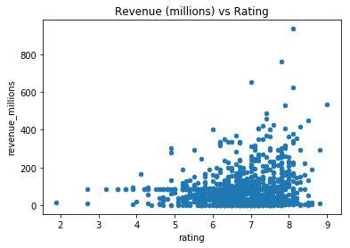

```python
movies_df.plot(kind='scatter', x='rating', y='revenue_millions', title='Revenue (millions) vs Rating');
```

What's with the semicolon? It's not a syntax error, just a way to hide the `<matplotlib.axes._subplots.AxesSubplot at 0x26613b5cc18>` output when plotting in Jupyter notebooks.

If we want to plot a simple Histogram based on a single column, we can call plot on a column:

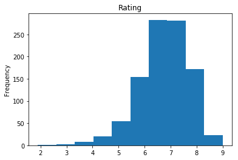

```python
movies_df['rating'].plot(kind='hist', title='Rating');
```

Do you remember the `describe` example at the beginning of this tutorial? Well, there's a graphical representation of the interquartile range, called the Boxplot. Let's recall what `describe` gives us on the ratings column:

```python
movies_df['rating'].describe()
```

```
count    1000.000000
mean        6.723200
std         0.945429
min         1.900000
25%         6.200000
50%         6.800000
75%         7.400000
max         9.000000
Name: rating, dtype: float64
```

Using a Boxplot we can visualize this data:

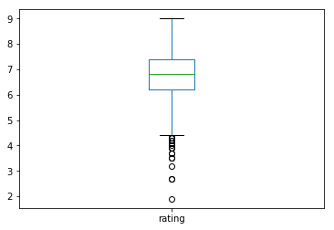

```python
movies_df['rating'].plot(kind="box");
```

[figure not shown]

Source: *Flowing Data*

By combining categorical and continuous data, we can create a Boxplot of revenue that is grouped by the Rating Category we created above:

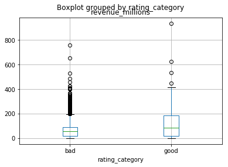

```python
movies_df.boxplot(column='revenue_millions', by='rating_category');
```

That's the general idea of plotting with pandas. There's too many plots to mention, so definitely take a look at the `plot` [docs here](https://pandas.pydata.org/pandas-docs/stable/user_guide/visualization.html) for more information on what it can do.

## Wrapping up

Exploring, cleaning, transforming, and visualization data with pandas in Python is an essential skill in data science. Just cleaning wrangling data is 80% of your job as a Data Scientist. After a few projects and some practice, you should be very comfortable with most of the basics.

To keep improving, view the [extensive tutorials](https://pandas.pydata.org/pandas-docs/stable/tutorials.html) offered by the official pandas docs.